# Lecture 3

Giuseppe Ragusa

## Introduction

Last time we have spoken about the compromise between bias and variance:

- The higher the flexibility of the model , the lower the bias, but the higher the variance.
- The more a model is simple, the lower the variance but the higher the bias

# Linear Model: Review

$$\begin{equation}
\nonumber
y_i = \beta_0 + \beta_1 x_{1,i} + ... + \beta_k x_{k,i} + \epsilon_i
\end{equation}$$

In a more compact way:

$$\begin{equation}
\hat{Y}= X\beta
\end{equation}$$

The OLS estimators solve:
$$\begin{equation}
\nonumber
\hat{\beta}^{OLS} = \underset{\hat{\beta}}{\operatorname{argmin}} \sum_{i=1}^n (y_i - X_i\beta)^2
\end{equation}$$

Taking the linear projection of Y onto X:

$$\begin{equation}
\nonumber
\frac{dRSS(\beta)}{\beta} = 0 \rightarrow \hat{\beta^{OLS}} = (X'X)^{-1}X'Y
\end{equation}$$

The general formula of the standard error:

$$\begin{equation}
Var(\hat{\beta^{OLS}}) = (X^TX)^{-1} (\sum_{i=1}^n \epsilon_i^2 x_i^Tx_i) (X^TX)^{-1}
\end{equation}$$

And under the assumption of homoskedasticity:

$$\begin{equation}
\nonumber
Var(\hat{\beta}^{OLS}) = \sigma^2 (X'X)^{-1}
\end{equation}$$

**What happen if some variable are highly correlated each other?**

To avoid singularity problems of the (X’X) matrix you can add a ridge to the matrix:

$$\begin{equation}
\nonumber
\hat{\beta}^{RR} = (X'X + \lambda I) X'Y
\end{equation}$$

Where
$$I =
\begin{bmatrix}
1 & 0 & 0 & ... & 0 \\
0 & 1 & 0 & ... & 0 \\
: & : & : & : & 0\\
0 & 0 & 0 & ... &1 \\
\end{bmatrix}$$
and $\lambda > 0$

Note: for any $\lambda > 0$ $(X'X)$ is not singular, why?

This is equivalent to solve

$$\begin{equation}
\nonumber
\underset{\hat{\beta}}{\operatorname{min}} \sum_{i=1}^n (y_i - X_i\beta)^2
\end{equation}$$

subject to

$$\begin{equation}
\nonumber
\sum_{j=1}^p \beta_j^2 < C
\end{equation}$$

with $C > 0$

Which is equivalent to…

$$\begin{equation}
\nonumber
\hat{\beta}^{RR} = \underset{\hat{\beta}}{\operatorname{argmin}} \sum_{i=1}^n (y_i - X_i\beta)^2 + \lambda \sum_{j=1}^p \beta_j^2
\end{equation}$$

- If $\lambda \rightarrow \infty$ then $\hat{\beta}^{RR} \rightarrow 0$
- If $\lambda = 0$ then $\hat{\beta}^{RR} = \hat{\beta}^{OLS}$

# Ridge Regression

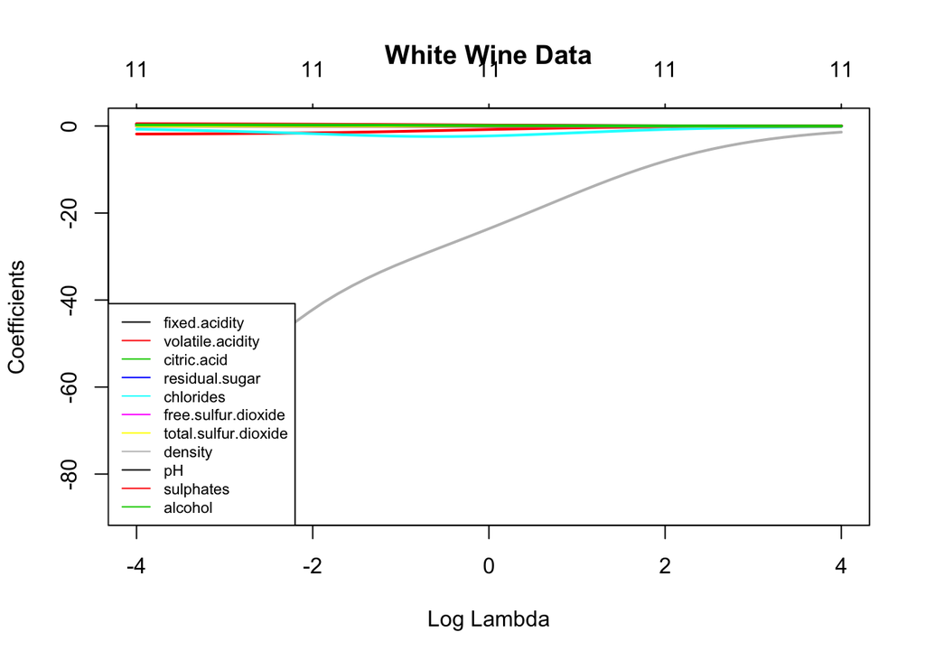

```r
## Costruct a sequence for lambda

wine.white <- read.table("./data/wine-white.txt")
library(glmnet)
lambdas.rr <- exp(seq(-4, 4, length = 50))
y <- wine.white$quality

## Construct the covariate matrix
X <- as.matrix(wine.white[,-12])
fit <- glmnet(
  x = X,
  y = y,
  lambda = lambdas.rr,
  alpha = 0
  )

# alpha = 1 for lasso, alpha = 0.5 for elastic net with 0.5 alpha

# Standardize
p <- ncol(X)
n <- nrow(X)
xmn <- scale(X, center = FALSE, scale = rep(sqrt(n - 1), p))

fit <- glmnet(
  x = X,
  y = y,
  lambda = lambdas.rr,
  alpha = 0
  )

## Add a legend

lbs_fun <- function(fit, ...) {
  L <- length(fit$lambda)
  x <- log(fit$lambda[L])
  y <- fit$beta[, L]
  labs <- names(y)
  legend(
    'bottomleft',
    legend = labs,
    col = 1:length(labs),
    lty = 1,
    cex = 0.7
    )
}

plot(
  fit,
  xvar = "lambda",
  col = 1:dim(coef(fit))[1],
  main = "White Wine Data",
  lwd = 2
  )
lbs_fun(fit)
```

- Ridge Regression was born to avoid problems of non-singularity.
- But in addition, it also reduces the variance of the parameters.
- The formula of the variance under homoskedastic error for ridge regression now:
  $$\begin{equation}
  \nonumber
  Var(\hat{\beta}^{RR}) = \sigma^2 (X'X + \lambda I)^{-1}
  \end{equation}$$
  So the higher $\lambda$ the lower the variance.

#### But what about the bias?

**If the gain in terms of variance is higher then the loss in terms of bias, then we should expect an higher predictive power of the model.**

We can choose among a set of models with different values of lambda.

# EDF

Ridge regression $\textbf{shrink}$ parameters to zero, but we still have the same number of variables, so nothing change?… Isn’t it?

How many **effective parameters** are we estimating?

**Example**

How many parameter do you have to estimate if you constrain your variables to be on the circular shape?

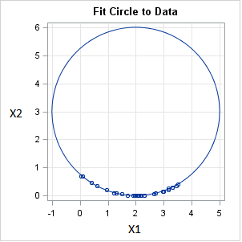

…Just one: the angle of the circle!

**Effective degrees of freedom** are the number of parameters to be estimated. In case of OLS regression this number is equal to p, where p is the number of variables plus one (the intercept).

$$\begin{equation}
\nonumber
EDF = trace(S) = \sum_{i=1}^n S_{i,i}
\end{equation}$$

For linear regression:

$$\begin{equation}
\nonumber
S = X(X'X)^{-1}X'
\end{equation}$$

For ridge regression:

$$\begin{equation}
\nonumber
S = X(X'X + \lambda I)^{-1}X'
\end{equation}$$

What is the trace?

Using the Singular Value Decomposition

$$\begin{equation}
\nonumber
X = UDV'
\end{equation}$$

with

$U'U = V'V = I$ and

$$D =
\begin{bmatrix}
d_1 & 0 & 0 & ... & 0 \\
0 & d_2 & 0 & ... & 0 \\
: & : & : & : & 0\\
0 & 0 & 0 & ... &d_j \\
\end{bmatrix}$$

$$EDF = \sum_1^j \frac{d_j}{d_j + \lambda}$$

But…

- What lambda represents?
- How do I choose lambda?

So..

How do we choose lambda?

- Minimum in-sample MSE
- Minimum R squared
- Maximum R squared
- Minimum out-of-sample MSE
- As usual… We do not care

**Cross Validation!**

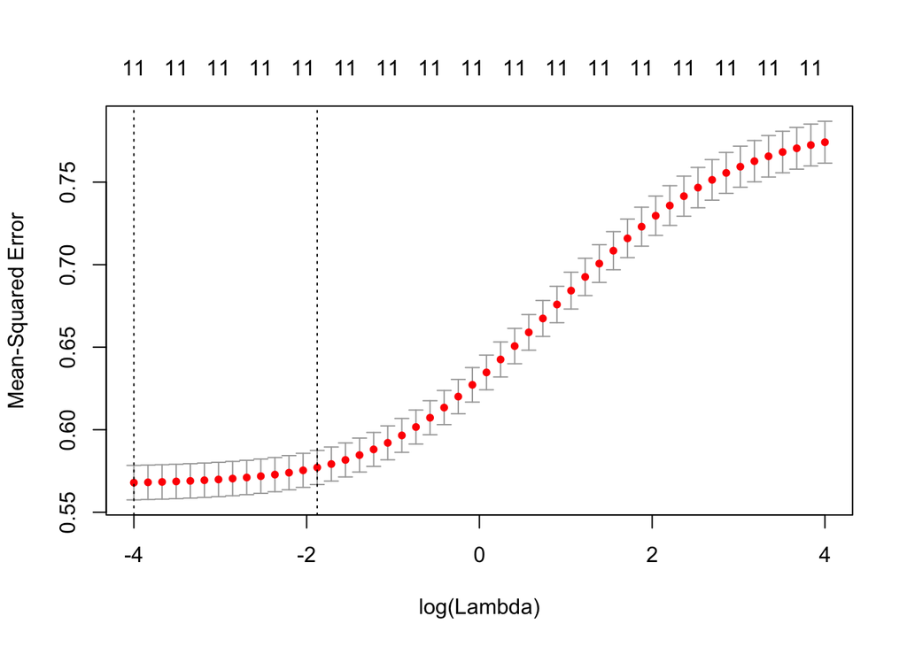

```r
## Cross validation

library(glmnet)
lambdas.rr <- exp(seq(-4, 4, length=50))
k <- 10
rr.cv <- cv.glmnet(x=X, y=y, lambda=lambdas.rr, nfolds=k, alpha=0)
fit <- glmnet(x=X, y=y, lambda=rr.cv$lambda.min, alpha=0)



plot(rr.cv)
```

But an alternative method may be…
$$\beta^{Lasso} = \underset{\beta}{\operatorname{argmin}} (Y - X\beta)'(Y - X\beta) + \lambda |\beta|$$

So…Which one?

**Differences**

- Lasso shrink some coefficients to zero after a certain treshold for lambda (features selection).
- Ridge never shrinks coefficients completely to zero.

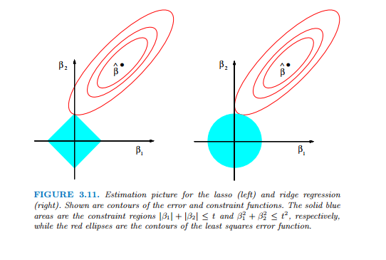

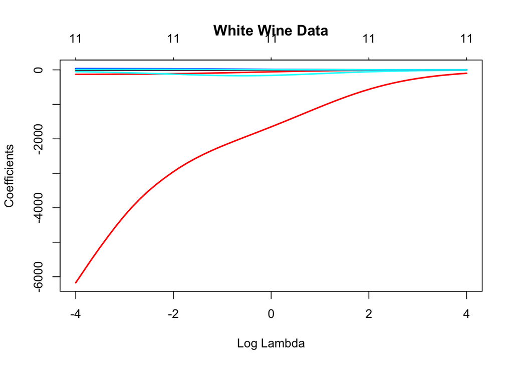

```r
fit <- glmnet(x=as.matrix(xmn), y=y, lambda=lambdas.rr, alpha=0)
plot(fit, xvar='lambda', lwd=2, main= "White Wine Data")
```

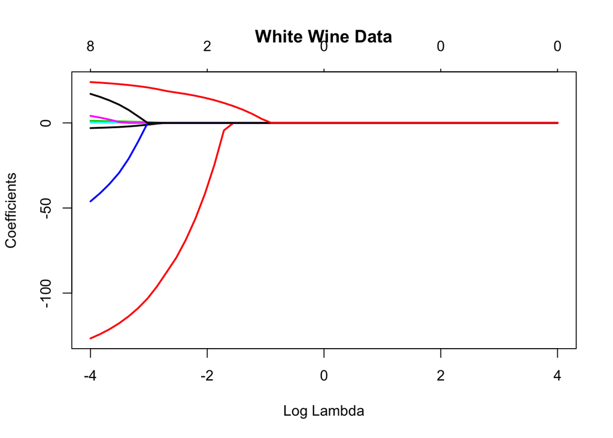

```r
fit <- glmnet(x=as.matrix(xmn), y=y, lambda=lambdas.rr, alpha=1)
plot(fit, xvar='lambda', lwd=2, main= "White Wine Data")
```

And with cross validation…

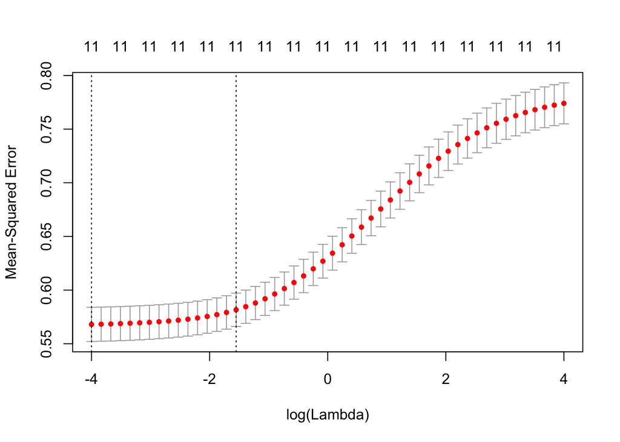

```r
lambdas.rr <- exp(seq(-4, 4, length=50))
k <- 10
rr.cv <- cv.glmnet(x=as.matrix(xmn), y=y, lambda=lambdas.rr, nfolds=k, alpha=0)
plot(rr.cv)
```

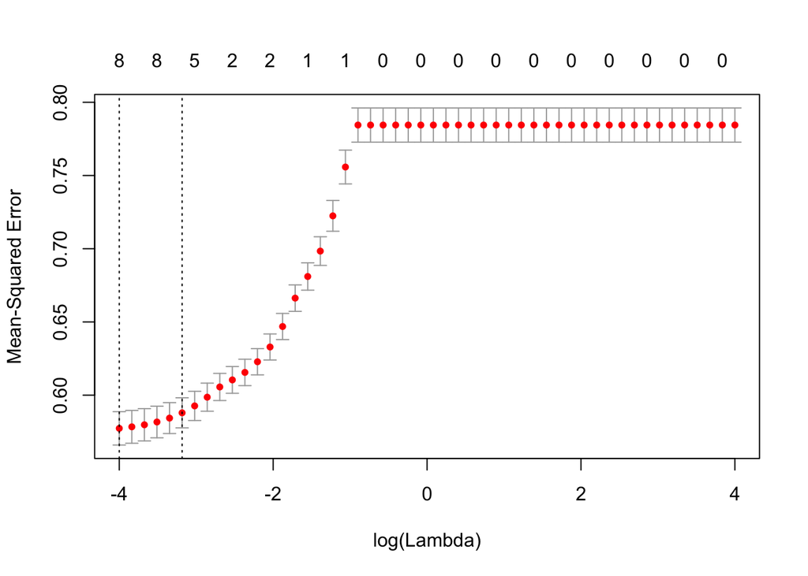

```r
lambdas.rr <- exp(seq(-4, 4, length=50))
k <- 10
rr.cv <- cv.glmnet(x=as.matrix(xmn), y=y, lambda=lambdas.rr, nfolds=k, alpha=1)
plot(rr.cv)
```

- Lasso shrinks some coefficients to zero after a certain treshold for lambda
- Ridge never shrinks coefficients to zero

Moreover:

- Lasso picks at most as many covariates as the observations(no overidentifed models)
- When covariates are highly correlated Lasso will tend to pick just one of them

But you might want to have a predictor between the two:

$$\begin{equation}
\beta^{ElNet} = \underset{\beta}{\operatorname{argmin}} (Y - X\beta)'(Y - X\beta) + \lambda (\alpha |\beta| + (1 - \alpha) \beta^2)
\end{equation}$$

# Example

We are still interested in predicting what is the expected quality of a wine controlling for chemical attributes.

Previously we showed the result of the analysis, here we provide further details on some issues to be careful about.

The data set is available on the web page.

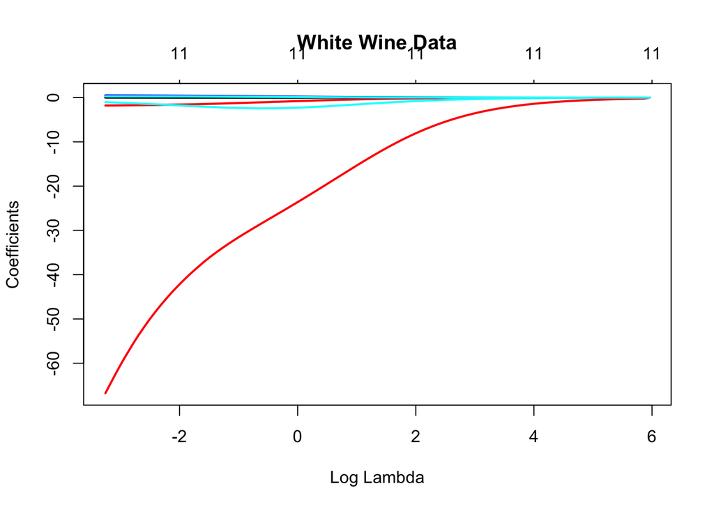

```r
## Costruct a sequence for lambda

wine.white <- read.table("./data/wine-white.txt")

X = model.matrix(quality ~ ., data = wine.white)
y  = wine.white$quality

# alpha = 1 for lasso, alpha = 0.5 for elastic net with 0.5 alpha
fit <- glmnet(X, y, alpha=0, standardize = TRUE)


## Make a plot of coefficients
plot(fit, xvar='lambda', lwd=2, main= "White Wine Data")
```

## Cross validation

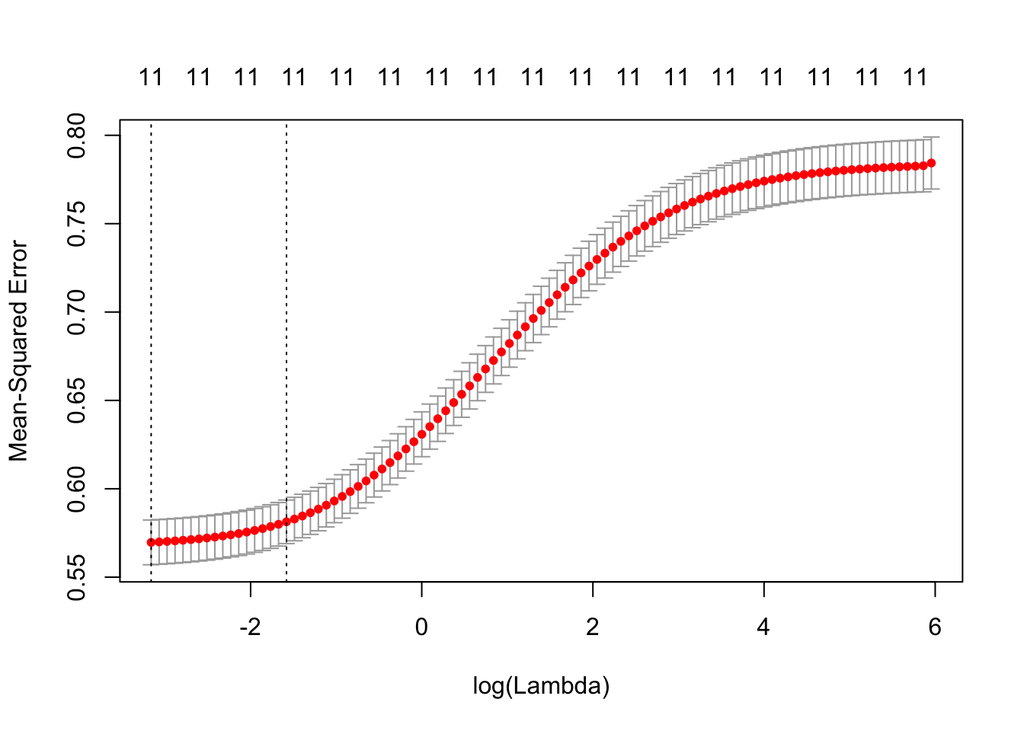

```r
k <- 10
rr.cv <- cv.glmnet(x=X, y=y, nfolds=k, alpha=0)
plot(rr.cv)
```

```r
## Get lambda associated with lowest MSE
lambda_min_mse = rr.cv$lambda.min
## Or the largest lambda with MSE not significantkly different the the smallest
lambda_min_mse = rr.cv$lambda.1se
```

## A more complicated model

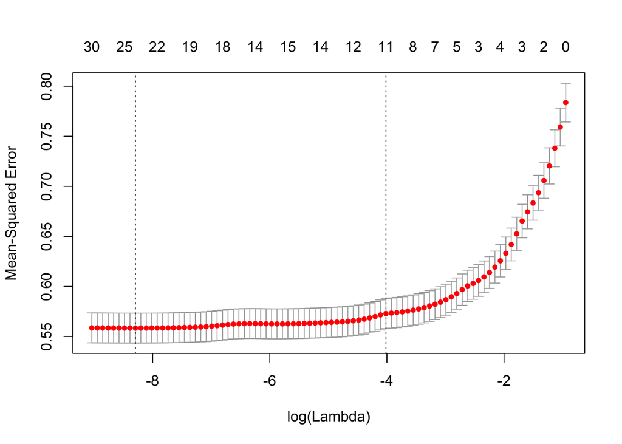

```r
X = model.matrix(quality ~ . +
                 fixed.acidity*alcohol +
                 fixed.acidity*alcohol*pH +
                 fixed.acidity*residual.sugar*pH +
                 residual.sugar*pH*alcohol+
                 I(alcohol^2) + I(sulphates^2) + I(pH^2) +
                 I(alcohol^3) + I(sulphates^3) + I(pH^3) +
                 I(alcohol^4) + I(alcohol*sulphates^3) + I(alcohol*pH^3) +
                 I(alcohol^2) + I(alcohol*sulphates^2) + I(alcohol*pH^2) +
                 I(density^2) + I(density^3) + density*pH*residual.sugar+
                 pH*alcohol, data = wine.white)
y  = wine.white$quality
rr.cv <- cv.glmnet(x=X, y=y, nfolds=20, alpha=1)
plot(rr.cv)
```

## Exercise

We are interested in predicting the level of alchol consumption during the weekend for students, controlling for many social and academic indicators. Some of them are the average grades for three years, the income of the family, the age, etc. In total we have 32 variables, but we want to find just the ones most correlated with alchol consumption.

Which model would you use?

Do the following:

- Download the student txt file

```r
student <- read.table("./data/student.matG.txt")
```

- Explore the variables and construct two different linear models
- Report the interpretation of the coefficients

Note: the dependent variable is Walc (Week-end alchol consumption)

```r
### Exercise Student

student <- read.table("./data/student.matG.txt")

reg1 <- lm(Walc~school, data=student)
reg2 <- lm(Walc~ school + age + health + school*health , data=student)

summary(reg1)
```

```
##
## Call:
## lm(formula = Walc ~ school, data = student)
##
## Residuals:
##     Min      1Q  Median      3Q     Max
## -1.5217 -1.2607 -0.2607  0.7393  2.7393
##
## Coefficients:
##             Estimate Std. Error t value Pr(>|t|)
## (Intercept)  2.26074    0.06888  32.821   <2e-16 ***
## schoolMS     0.26099    0.20184   1.293    0.197
## ---
## Signif. codes:  0 '***' 0.001 '**' 0.01 '*' 0.05 '.' 0.1 ' ' 1
##
## Residual standard error: 1.287 on 393 degrees of freedom
## Multiple R-squared:  0.004236,   Adjusted R-squared:  0.001703
## F-statistic: 1.672 on 1 and 393 DF,  p-value: 0.1968
```

```r
summary(reg2)
```

```
##
## Call:
## lm(formula = Walc ~ school + age + health + school * health,
##     data = student)
##
## Residuals:
##     Min      1Q  Median      3Q     Max
## -1.8027 -1.2238 -0.2779  0.8379  3.1672
##
## Coefficients:
##                  Estimate Std. Error t value Pr(>|t|)
## (Intercept)     -0.001606   0.938437  -0.002   0.9986
## schoolMS         0.225423   0.520777   0.433   0.6654
## age              0.115782   0.054790   2.113   0.0352 *
## health           0.097726   0.049720   1.966   0.0501 .
## schoolMS:health -0.035411   0.140793  -0.252   0.8016
## ---
## Signif. codes:  0 '***' 0.001 '**' 0.01 '*' 0.05 '.' 0.1 ' ' 1
##
## Residual standard error: 1.279 on 390 degrees of freedom
## Multiple R-squared:  0.02451,    Adjusted R-squared:  0.0145
## F-statistic: 2.449 on 4 and 390 DF,  p-value: 0.04577
```

Now:

Remember to set `alpha = 1`.

```r
## Expand matrix

xm <- model.matrix(~. ,data=student[,-27])[,-1]
y <- student[,27]

## Use this functions to standardize

standard_for_dummy <- function (k){ if (length(k[!duplicated(k)])==2)
{ return(1)}
return(sd(k))                                                      }

sd.tr <- apply(xm, 2, standard_for_dummy)

mu_for_dummy <- function (k){ if (length(k[!duplicated(k)])==2)
{ return(0.5)}
mean(k)      }

mu.tr <-apply(xm, 2, mu_for_dummy)

## New covariate matrix


xmn <- scale(xm, center = mu.tr, scale=sd.tr)

## Set your lambda

lambdas.rr <- exp(seq(-4, 4, length=50))
```

**Solution:**

```r
k <- 10

lr.cv <- cv.glmnet(x=as.matrix(xmn), y=student[,27], lambda=lambdas.rr, nfolds=k, alpha=1)


fit <- glmnet(x=as.matrix(xmn), y=y, lambda=lr.cv$lambda.min, alpha=1)
```

Finally:

- Cross Validate the linear model using the skeleton for cross validation provided
- Assess which model is the best
- Do you think it is the correct way to compare the models?

Optional:

- Use fit$beta to see the coefficients actually used by the best lasso
- Question: do you think it is a proper way to assess causality between variables? Why or why not?

**Solution**

```r
set.seed(123)

  n <- length(y)
  k <- 10

  ii <- sample(rep(1:k, length= n))

  pr.1 <- pr.2 <- rep(NA, length(y))
  for (j in 1:k){
    hold <- (ii == j)
    train <- (ii != j)


  reg1 <- lm(Walc~school, data=student[train,])
  reg2 <- lm(Walc~ school + age + health + school*health , data=student[train,])

   pr.1[hold] <- predict(reg1, newdata=student[hold,])
    pr.2[hold] <- predict(reg2, newdata=student[hold,])

  }

mspe1 <- mean((pr.1-y)^2)
mspe2 <- mean((pr.2-y)^2)

print(cbind(mspe1, mspe2))
```

```
##         mspe1    mspe2
## [1,] 1.655833 1.650803
```

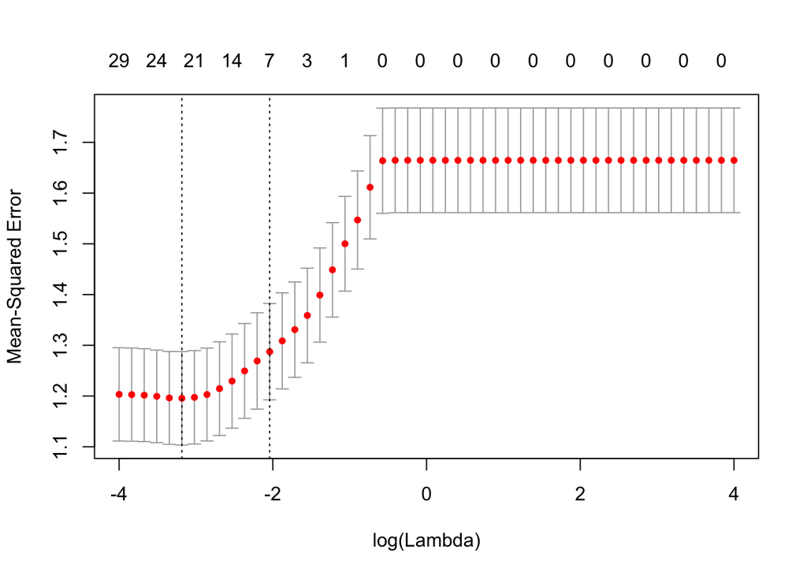

```r
plot(lr.cv)
```

**Correct way:**

```r
set.seed(123)

  n <- length(y)
  k <- 10

  ii <- sample(rep(1:k, length= n))

  pr.1 <- pr.2 <- pr.l <- rep(NA, length(y))
  for (j in 1:k){
    hold <- (ii == j)
    train <- (ii != j)
    xx.tr <- xmn[train,]
    y.tr <-  y[train]
    xx.te <- xmn[hold,]

  reg1 <- lm(Walc~school, data=student[train,])
  reg2 <- lm(Walc~ school + age + health + school*health , data=student[train,])



    ### find the best ridge on the TRAINING SET!
    lr.cv <- cv.glmnet(x=as.matrix(xx.tr), y=y.tr, lambda=lambdas.rr, nfolds=k, alpha=1)


fit <- glmnet(x=as.matrix(xx.tr), y=y.tr, lambda=lr.cv$lambda.min, alpha=1)

    pr.1[hold] <- predict(reg1, newdata=student[hold,])
    pr.2[hold] <- predict(reg2, newdata=student[hold,])

    pr.l[hold] <- predict(fit, newx=xx.te)
  }

mspe1 <- mean((pr.1-y)^2)
mspe2 <- mean((pr.2-y)^2)
mspe.Lasso <- mean((pr.l-y)^2)
print(cbind(mspe1, mspe2, mspe.Lasso))
```

```
##         mspe1    mspe2 mspe.Lasso
## [1,] 1.655833 1.650803   1.184304
```

**Why did we cross validated twice?**

The choice of lambda is done by cross validating the whole data set and THEN using the minimum lambda for constructing the regression. By doing so the regression becomes:

$$\begin{equation}
\nonumber
\hat{Y}= S_\lambda Y
\end{equation}$$

Where $S_\lambda$ is chosen looking at in-sample observations.

But to have an unbiased estimator we need always out-of-sample information.

The correct way of doing cross validation is:

- Randomly divide the data in k folds
- Find the tuning parameter (lambda) on k-1 folds
- Train the model on k-1 folds
- Compute the MSPE on the remaining fold
- Repeat the process k times and pick the mean for the MSPE

Every time you must cross validate everything, also the way you select the model!

**Optional Question: Solution**

```r
lambdas.rr <- exp(seq(-4, 4, length=50))

k <- 10

lr.cv <- cv.glmnet(x=as.matrix(xmn), y=student[,27], lambda=lambdas.rr, nfolds=k, alpha=1)


fit <- glmnet(x=as.matrix(xmn), y=y, lambda=lr.cv$lambda.min, alpha=1)

fit$beta
```

```
## 40 x 1 sparse Matrix of class "dgCMatrix"
##                            s0
## schoolMS          .
## sexM              0.490585276
## age               0.021504423
## addressU         -0.225973581
## famsizeLE3        0.121385336
## PstatusT          .
## Medu             -0.018117504
## Fedu              .
## Mjobhealth        .
## Mjobother         .
## Mjobservices      .
## Mjobteacher       .
## Fjobhealth        .
## Fjobother         0.060404901
## Fjobservices      0.232564592
## Fjobteacher      -0.234248942
## reasonhome        .
## reasonother       0.183988257
## reasonreputation  .
## guardianmother   -0.012841937
## guardianother    -0.157157040
## traveltime        0.058417780
## studytime        -0.157395739
## failures          0.018325220
## schoolsupyes      .
## famsupyes        -0.032471971
## paidyes           0.243145424
## activitiesyes    -0.085106738
## nurseryyes       -0.208000612
## higheryes         .
## internetyes       .
## romanticyes       .
## famrel           -0.154080537
## freetime          .
## goout             0.482052557
## health            0.067987036
## absences          0.117123906
## G1               -0.004467456
## G2                .
## G3                .
```

**Question: do you think it is a proper way to assess causality between variables? Why or why not?**

No, it is not a proper way to find causal relationship among variables. In fact if some variables are highly correlated each other just one or few of these variables will enter in the regression, but this does not mean that they have a causal relationship with the dependent variable.

For example in our case mother education (Meduc) enters in the regression, while father education (Feduc) does not. Probably the variables are highly correlated(same education of husbands) and just one of the two enter in the regression (the other is masked). But still… Also father education may have an effect on alchol consumption of the son!

# Optional Challenge

We want to predict the waiting time for a bus in Rome at a certain stop. To do so, we have collected data from Atac, the firm who manages the public traffic service between April and May 2016. We have at disposal 193 variables and the dependent variable is travel time between two points of the city. The only objective is to have an accurate out-of-sample predictive power.

Which model would you use? How would you choose the model?

Open the text file Atacfinal and set the dependent variable the 160th columns (Hint: use y = data[,160], xm = data[,-160]).

- Construct a lasso regression and an elastic net regression with alpha = 0.5.
- Use cross validation to choose the best lambda in each case and compare the values of lambda.
- Plot the behaviour of the MSPE as a function of lambda for the lasso regression and elastic net regression.
- Which difference do you notice? Which one do you prefer? How many variables would you use?

Hint: Remember to standardize covariates!

```r
## Challenging exercise: Atac

data <- read.table("./data/Atacfinal.txt")

y <- data[,160]
xm <- data[,-160]

## Standardize covariates


standard_for_dummy <- function (k){ if (length(k[!duplicated(k)])==2)
{ return(1)}
return(sd(k))                                                      }

sd.tr <- apply(xm, 2, standard_for_dummy)

mu_for_dummy <- function (k){ if (length(k[!duplicated(k)])==2)
{ return(0.5)}
mean(k)      }

mu.tr <-apply(xm, 2, mu_for_dummy)

## New covariate matrix


xmn <- scale(xm, center = mu.tr, scale=sd.tr)

## Set your lambda

lambdas.rr <- exp(seq(-4, 4, length=50))

k <- 10

lr.cv <- cv.glmnet(x=as.matrix(xmn), y=y, lambda=lambdas.rr, nfolds=k, alpha=1)


fit.lasso <- glmnet(x=as.matrix(xmn), y=y, lambda=lr.cv$lambda.min, alpha=1)

en.cv <- cv.glmnet(x=as.matrix(xmn), y=y, lambda=lambdas.rr, nfolds=k, alpha=0.5)


fit.net <- glmnet(x=as.matrix(xmn), y=y, lambda=rr.cv$lambda.min, alpha=0.5)

plot(lr.cv)

plot(en.cv)


## See the number of variables


par(mar = c(5,5,3,5))


plot(lr.cv)

par(new = T)
plot(lr.cv$nzero ~ lr.cv$lambda, xlab=NA, ylab =NA, type="n", axes=F)
axis(side = 4)
mtext(side = 4, line = 3, 'Number of Variables')
lines(lr.cv$nzero ~ lr.cv$lambda, xlab="lambda", ylab ="Number of variables", col="blue")
```